# Domowa_5

Paweł Morgen

## Struktura ankiety

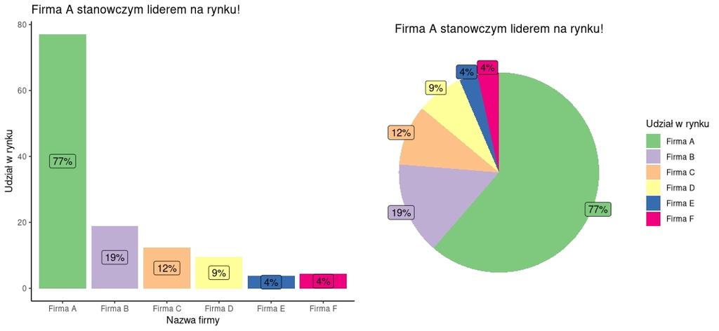

Badanie przeprowadzono bezpośrednio na próbce złożonej z 18 osób zróżnicowanych pod względem wieku i płci. Badany miał przez cały czas dostęp do zdjęcia dwóch wykresów (zamieszczone powyżej). Badany odpowiadał na 4 pytania:

1. Który wykres uważasz za ładniejszy? (Bardziej estetyczny, elegencki itp)
2. Jaki element wykresów zauważyłeś najpierw?
3. Z którego wykresu łatwiej odczytać różnicę między Firmą C i Firmą D?
4. Czy zauważyłeś, że wartości liczbowe nie sumują się do 100?

## Pytanie 1

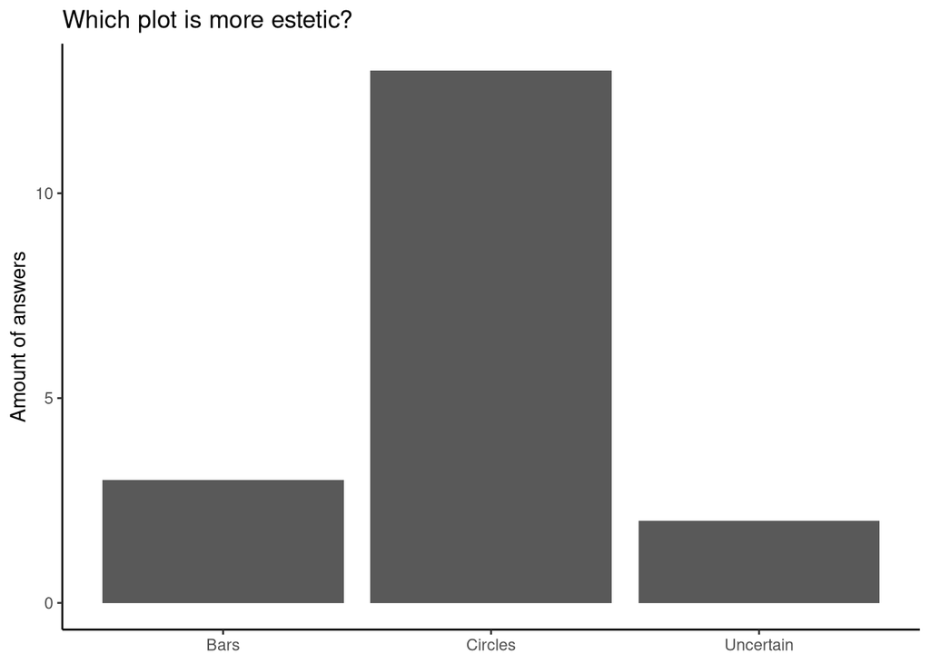

Jak widzimy, zdecydowana większość ankietowanych uważa wykres kołowy za ładniejszy.

## Pytanie 2

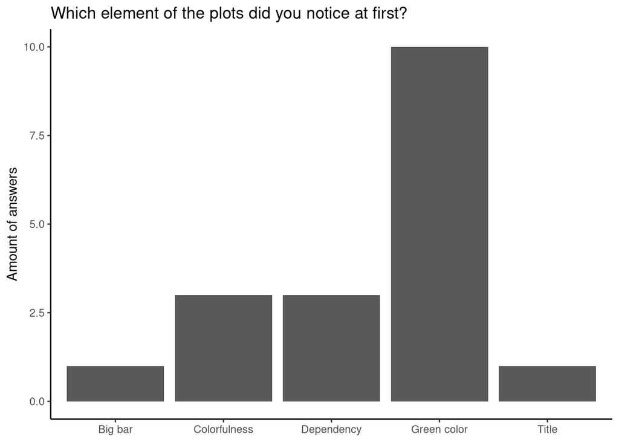

## Pytanie 3

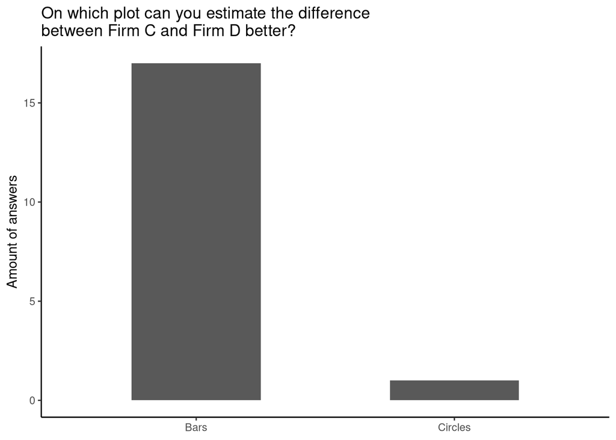

Prawie wszyscy zgadzają się, że dane łatwiej odczytać z wykresu słupkowego.

## Pytanie 4

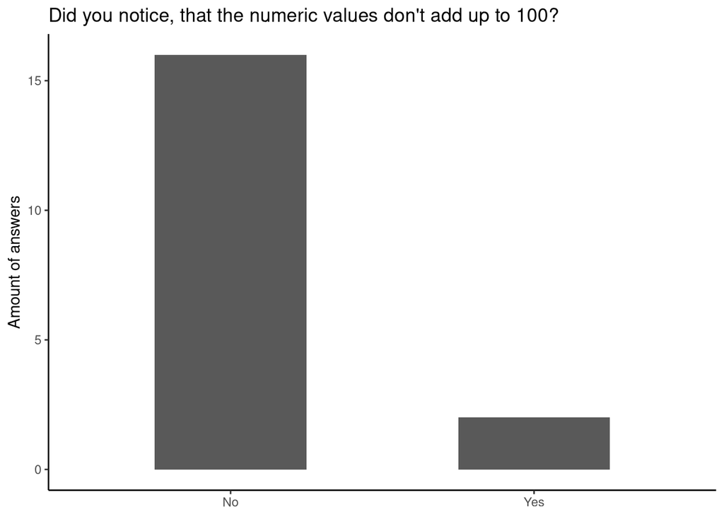

Prawie nikt nie zauważył nieprawidłowości. Mało tego - niewiele osób w ogóle zwróciło uwagę na dane liczbowe.

## Komentarz

Praca potwierdza tezy stawiane na wykładach - kolory jako pierwsze rzucają się w oczy (a więc niepotrzebne kolorowanie wykresów rozprasza uwagę) oraz dane łatwiej czytać z wykresów słupkowych. Warto zwrócić uwagę na fakt, że pomimo tego ludzie traktują wykresy kołowe jako ładniejsze. Tłumaczy to ich sporą obecność w mediach oraz oznacza, że prędko one nie znikną. Stawia również pytanie, czy w określonych przypadkach warto *odrobinę* zmniejszyć czytelność, by zyskać na estetyce.

## Źródła

Wyniki mam udokumentowane w formie listy z podpisami ankietowantch. Kod generujący wykresy do ankiety znajduje się poniżej:

```r
data2 <- data.frame(value = c(70, 17.5, 12.5, 10, 5, 3) + rnorm(6, sd = 3),
                    name = paste("Firma", LETTERS[1:6]))#,
data2$labpos <- cumsum(data2$value) - data2$value / 2

p1 <- ggplot(data2, aes(x = "",
                        y = value,
                        fill = name,
                        label = paste0(round(value), "%"))) +
  geom_bar(stat = "identity", position = position_stack(reverse = TRUE)) +
  geom_label(aes(x = 1.5, y = labpos),show.legend = FALSE) +
  scale_fill_brewer(type = "qual") +
  labs(fill="Udział w rynku",
       x=NULL,
       y=NULL,
       title = "Firma A stanowczym liderem na rynku!") +
  coord_polar(theta = "y") +
    theme(axis.line = element_blank(),
          axis.text = element_blank(),
          axis.ticks = element_blank(),
          plot.title = element_text(hjust=0.5))

p2 <- ggplot(data2, aes(x = name, y = value, fill = name)) +
  geom_bar(stat = "identity") +
  scale_fill_brewer(type = "qual") +
  xlab("Nazwa firmy") +
  ylab("Udział w rynku") +
  labs(title = "Firma A stanowczym liderem na rynku!") +
  geom_label(aes(label = paste0(round(value), "%"), y = value / 2)) +
  theme(legend.position = "none")
p <- gridExtra::grid.arrange(p2, p1, ncol = 2)
ggsave("plot_to_show.png")
```